# 04_htest

Brandon Lam

11/25/2021

## Analysis

To answer our question, we will perform a hypothesis testing. First, we’ll define $H_0$ and $H_A$ as below:

$H_0:$ the proportion of athletes under 25 that win a medal is equal to the proportion of athletes 25 and older that win a medal.

$H_A:$ the proportion of athletes under 25 that win a medal is greater to the proportion of athletes 25 and older that win a medal.

We will then

1. compute the observed test statistic from original sample,

2. use the null model to generate 100 random permuted samples from the original sample and calculate their corresponding r test statistics,

3. generate the null distribution using these r test statistics,

4. check if the observed test statistic computed in (1) falls on the distribution,

5. calculate the p-value to verify the result

The code used to perform the analysis and create this report can be found here: https://github.com/UBC-MDS/olympic_medal_htest

## Results & Discussion

Table 3. Data summary

| age | medal | n | prop |
| --- | --- | --- | --- |
| Under | 17939 | 131134 | 0.1368 |
| Above | 21112 | 130508 | 0.1618 |

There are 131,134 athletes under age of 25 and 13.68% of them got a medal in the event, while there are 130,508 athletes equal to or above the age of 25 and 16.18% of them got a medal in the event.

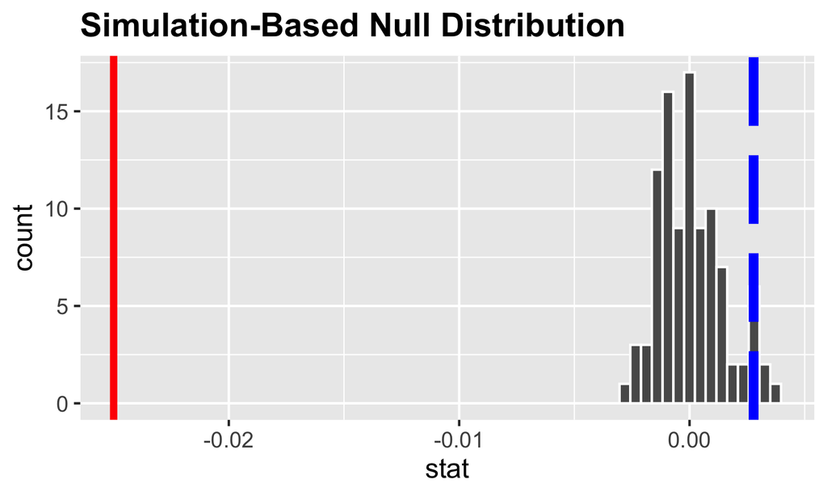

Figure 5. Hypothesis testing result

From figure 5, we can see that the observed test statistics (red line) fall within the significance threshold (blue line), we fail to reject $H_0$.

Table 4. p-value for the test.

| p-value |
| --- |
| 1 |

The p-value calculated is 1 and it is higher than the $\alpha$ of 0.05. It leads us to the same conclusion:

We fail to reject the null hypothesis and conclude that it is not statistically significant that the proportion of athletes younger than 25 that win a medal is greater than the proportion of athletes of age 25 or older that win a medal.